# P-value histograms

Is there any signal in your study?  
Or problems with your analysis?

Jaron Arbet

2025-01-23

## Motivation

- Project with large number of hypothesis tests
- Histogram of p-values gives a lot of info about your study
- Any **signal** in your study?
- **Quality control:** any problems with study design or analysis?
- Summarize the key results of (Breheny 2018)

## Hypothesis testing

**Null hypothesis ($H_0$)**

- No difference between groups
- No relationship between variables
- $\theta = \theta_0$

**Alternative hypothesis ($H_A$)**

- The groups differ
- There is a relationship between variables
- $\theta \neq \theta_0$

## What is a p-value?

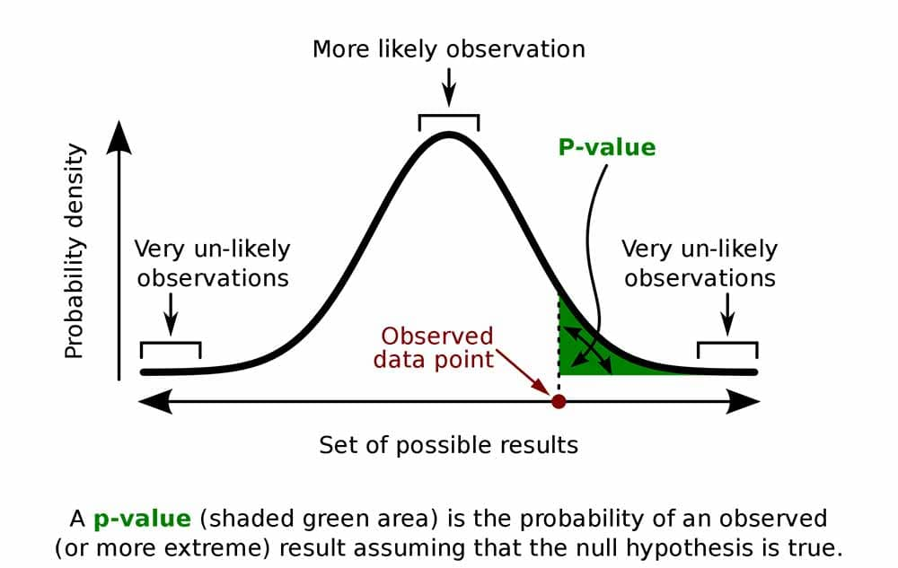

## When $H_0$ is always true

Flat/uniform distribution:

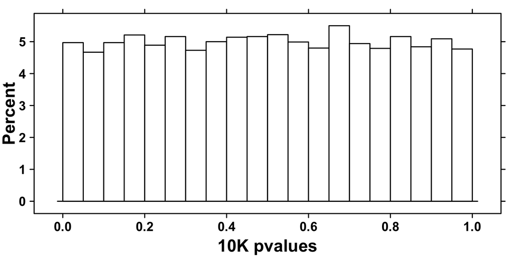

## When $H_A$ is sometimes true

Decreasing slope from left to right:

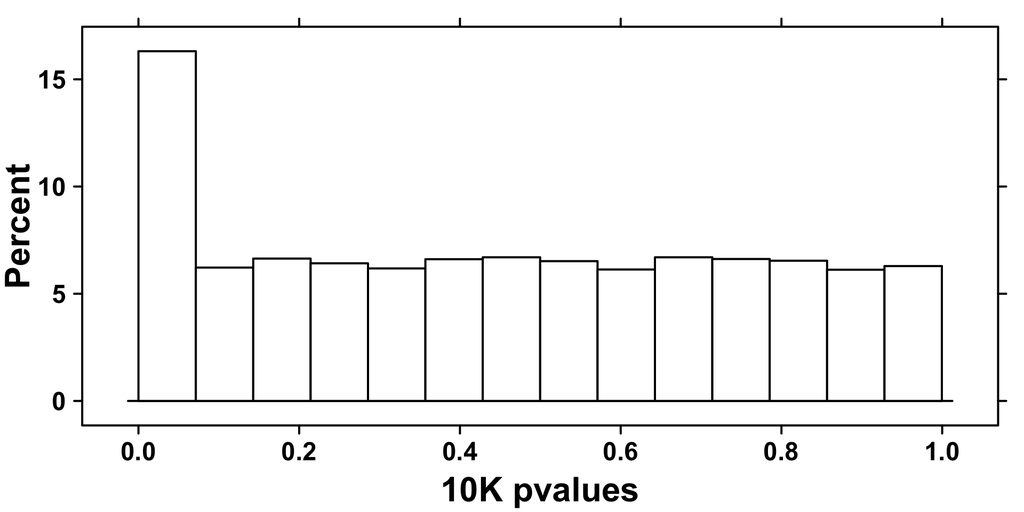

## Is there any signal in the data?

- (Rogier et al. 2014) mouse study with 201 genes
- No hypothesis rejected at 10% false discovery rate level

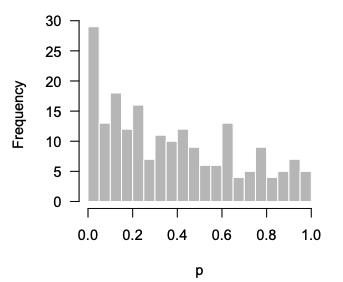

pvalue histogram suggests signal, but study was underpowered

## “Regular” pvalue histogram

(Breheny 2018) define a **regular** pvalue histogram as the 2 scenarios we’ve seen so far:

- **Flat/uniform** ($H_0$ is always true)
- **Slopes down left-to-right** ($H_A$ is sometimes true)

A regular pvalue histogram suggests no errors in your study/analysis , although you might still be underpowered

## “Irregular” pvalue histogram

(Breheny 2018) define an **irregular** pvalue histogram as any other shape, for example in (Fischl et al. 2014):

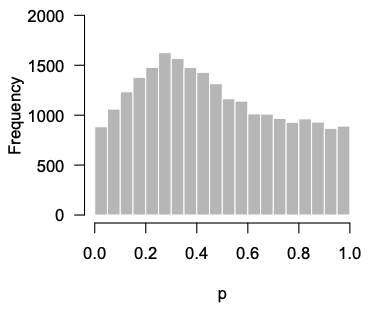

Suggests a problem in your study or analysis:

- Measurement error
- Parametric assumptions wrong
- Correlated pvalues (not major problem, need special considerations which we’ll come back to)

## Formal test for signal

- Let $\tau$ be the observed number of pvalues < 0.05
- 1-sided Binomial test: is $\tau$ greater than what’s expected assuming $H_0$ is always true?
- $m$ = number of tests
- $b$ = bin width of left-most bin (*e.g.* b = 0.05)
- Then 95th percentile of $Bin(m, b)$ is cutoff for the test
- Thus if $\tau > Bin_{.95}(m, b)$, we have evidence for a signal

## Example

- Recall (Rogier et al. 2014) 201 genes with min FDR $> 0.10$
- bin-width: $b = 0.05$
- $m$ = 201 tests
- Then $Bin_{.95}(m, b)$ =

```r
qbinom(p = 0.95, size = 201, prob = 0.05);
```

```
[1] 15
```

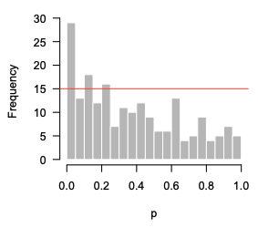

## QC test for irregular pvalue histogram

- The same idea can be used to test departures from uniformity anywhere between 0 and 1, not only near 0
- A binwidth of 0.05 gives 20 bins, and Bonferroni corrected $\alpha= 0.05/20 = 0.0025$, or the $Bin_{.9975}(m, b)$ percentile

**Example:**

- Recall the study of (Fischl et al. 2014)
- $m$ = 23,332 tests
- bin-width: $b = 0.05$
- Bonferroni corrected null threshold is:

```r
qbinom(p = 0.9975, size = 23332, prob = 0.05);
```

```
[1] 1261
```

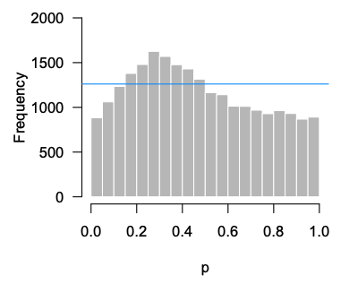

## Correlated pvalues

- All previous results assume the pvalues are independent
- Rarely true for cancer ’omic studies (e.g. correlated genes)

(Breheny 2018) propose a permutation method for the previous signal and QC tests that accounts for correlation:

- For example, test association between outcome $Y$ with gene expression matrix $X$
1. Permute $Y$ to remove relationship between $Y$ and $X$ while preserving the correlation structure of $X$
2. Rerun all tests on permuted dataset and record the pvalues
   - Obtains p-values from the null distribution without assuming independence
3. Record the count in the most highest bin from (2)
4. Repeat (1-3) 1000 times
5. The permutation-corrected **QC cutoff** is the 95th percentile of the distribution in (4)
   - Similarly, for the permutation-corrected **signal cutoff**, record the number of p<0.05 in each permutation dataset, then use 95th percentile of this distribution.

## Example:

Unpublished gene expression study

Histogram suggests problem, but genes are correlated:

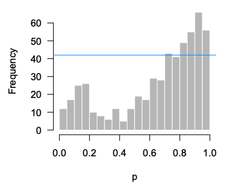

Permutation-corrected QC cutoff suggests no problem:

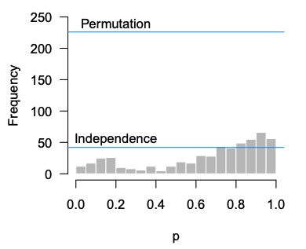

## Summary

- **Flat** pvalue histogram $H_0$ always true
- **Slopes down left-to-right** $H_A$ sometimes true
  - **Binomial test for signal**: far-left bin deviate from $H_0$?
  - If no tests significant after multiple testing correction, but the Binomial test is significant for an overall signal, this suggests your study was underpowered.
- **Irregular histograms** problem with analysis/study
  - **QC binomial test**: does *any* area of hist deviate from $H_0$?
  - Try a robust nonparametric method instead
  - Check measurement error or problems in study design
- **In practice**, apply the signal and QC tests assuming independence. If you exceed either threshold, try the permutation method to confirm.

## R function

```r
pvalue.histogram <- function(
    pvalues, # vector of pvalues
    b = 0.05, # width of each bin in histogram
    alpha = 0.05, # significance level of signal test
    ... # other args to create.histogram
    ) {
    stopifnot(all(is.numeric(pvalues)) & all(pvalues > 0) & all (pvalues < 1));
    stopifnot(length(b) == 1 & is.numeric(b) & b >= 0 & b <= 0.2);

    p.df <- data.frame(p = pvalues);
    m <- sum(!is.na(pvalues));
    signal.cutoff <- qbinom(
        p = 1 - alpha,
        size = m,
        prob = b
        );
    qc.cutoff <- qbinom(
        p = 1 - alpha / (1 / b),
        size = m,
        prob = b
        );
    BoutrosLab.plotting.general::create.histogram(
        x = p.df$p,
        ylab.label = 'Frequency',
        xlab.label = 'pvalues',
        breaks = seq(0, 1, by = b),
        type = 'count',
        abline.h = c(signal.cutoff, qc.cutoff),
        abline.col = c('red', 'blue'),
        abline.lwd = 3
        );
    }
```

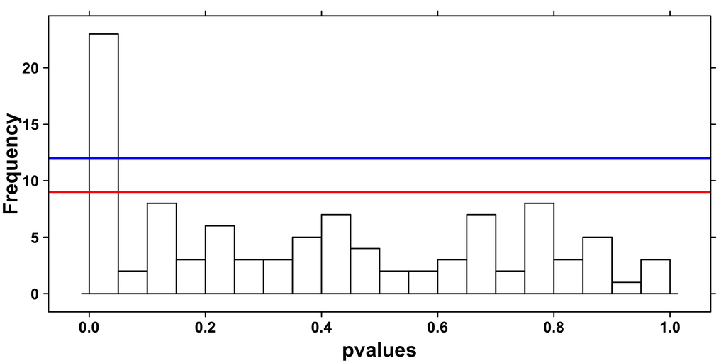

```r
# Example:
set.seed(123);
pvals <- c(
    runif(20, 0, 0.001),
    runif(80)
    );
pvalue.histogram(pvals);
```

**Signal** and **QC** thresholds

# References

Breheny, Patrick et al. 2018. “P-Value Histograms: Inference and Diagnostics.” *High-Throughput* 7 (3): 23.

Fischl, Adrian M, Paula M Heron, Arnold J Stromberg, and Timothy S McClintock. 2014. “Activity-Dependent Genes in Mouse Olfactory Sensory Neurons.” *Chemical Senses* 39 (5): 439–49.

Rogier, Eric W, Aubrey L Frantz, Maria EC Bruno, Leia Wedlund, Donald A Cohen, Arnold J Stromberg, and Charlotte S Kaetzel. 2014. “Secretory Antibodies in Breast Milk Promote Long-Term Intestinal Homeostasis by Regulating the Gut Microbiota and Host Gene Expression.” *Proceedings of the National Academy of Sciences* 111 (8): 3074–79.